# Hayman Fire Recovery

Samantha Clark

10/3/2019

```r
library(tidyverse)
library(tidyr)
library(ggthemes)
library(lubridate)
library(knitr)

# Now that we have learned how to munge (manipulate) data
# and plot it, we will work on using these skills in new ways

knitr::opts_knit$set(root.dir='.')
```

```r
####-----Reading in Data and Stacking it ----- ####
#Reading in files
files <- list.files('../data',full.names=T)


#Read in individual data files
ndmi <- read_csv(files[1]) %>%
  rename(burned=2,unburned=3) %>%
  mutate(data='ndmi')


ndsi <- read_csv(files[2]) %>%
  rename(burned=2,unburned=3) %>%
  mutate(data='ndsi')

ndvi <- read_csv(files[3])%>%
  rename(burned=2,unburned=3) %>%
  mutate(data='ndvi')

# Stack as a tidy dataset
full_long <- rbind(ndvi,ndmi,ndsi) %>%
  gather(key='site',value='value',-DateTime,-data) %>%
  filter(!is.na(value))
```

## Question 1

What is the correlation between NDVI and NDMI? - here I want you to convert the full_long dataset in to a wide dataset using the function “spread” and then make a plot that shows the correlation as a function of if the site was burned or not (x axis should be ndmi) You should exclude winter months and focus on summer months

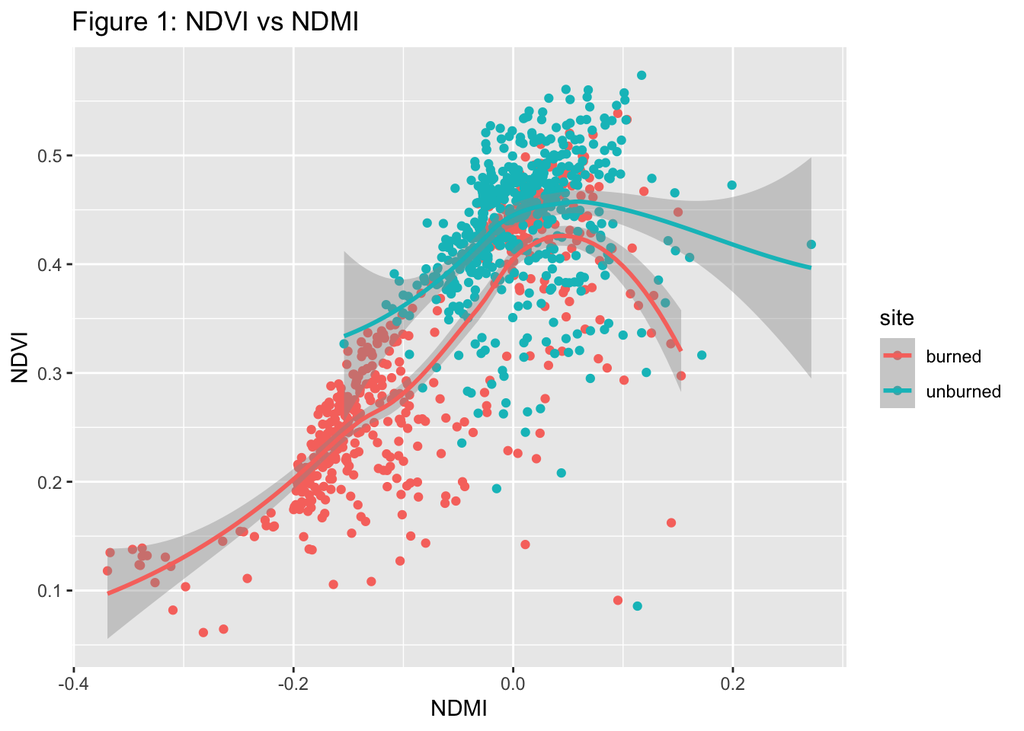

```r
# Convert data from long format to wide format
full_wide <- pivot_wider(full_long, names_from = "data", values_from = "value")

# Select months and plot NDVI vs NDMI
full_wide %>%
  mutate(month=month(DateTime), year=year(DateTime)) %>%
  filter(!month %in% c(9,10,11,12,1,2,3,4,5)) %>%
  ggplot(aes(x=ndmi, y=ndvi,color=site)) +geom_point() +geom_smooth() + ggtitle('Figure 1: NDVI vs NDMI') +xlab('NDMI') + ylab('NDVI')
```

Overall NDMI and NDVI are positively correlated, so as moisture increases, so does vegetation. However, at a certain point, when moisture becomes too high, vegetation no longer increases and either plateaus or decreases. This is understandable for instances of snow, or if vegetation has a very specific range of moisture in which it thrives. If the NDMI is above the vegetation’s upper moisture limit, the vegetation may begin to suffer, and therefore NDVI would decrease. There is also a difference between the trend for the unburned site and the burned site. Overall, vegetation is lower for the burned site no matter the moisture level. This makes sense as the burned site has fire damage, which will impact the vegetation for years after the fire. Overall, both of the trends are positively correlated to about the same point.

## Question 2

What is the correlation between average NDSI (normalized snow index) for January - April and average NDVI for June-August? In other words, does the previous year’s snow cover influence vegetation growth for the following summer?

```r
# Convert NDVI dataset
ndvi_long <- pivot_longer(ndvi, cols = c(burned, unburned), names_to = "site", values_to = "value") %>%
  filter(!is.na(value)) %>%
  transform(value = as.numeric(value))

#find averages for each year, for June- August
NDVI_avgs <- ndvi_long %>%
  mutate(month=month(DateTime), year=year(DateTime)) %>%
  filter(month %in% c(6,7,8)) %>%
  group_by(year, data) %>%
  summarize(mean = mean(value))
# Convert NDSI dataset
ndsi_long <- pivot_longer(ndsi, cols = c(burned, unburned), names_to = "site", values_to = "value") %>%
  filter(!is.na(value)) %>%
  transform(value = as.numeric(value))

#find averages for each year, for January-April
NDSI_avgs <- ndsi_long %>%
  mutate(month=month(DateTime), year=year(DateTime)) %>%
  filter(month %in% c(1,2,3,4)) %>%
  group_by(year, data) %>%
  summarize(mean = mean(value))
```

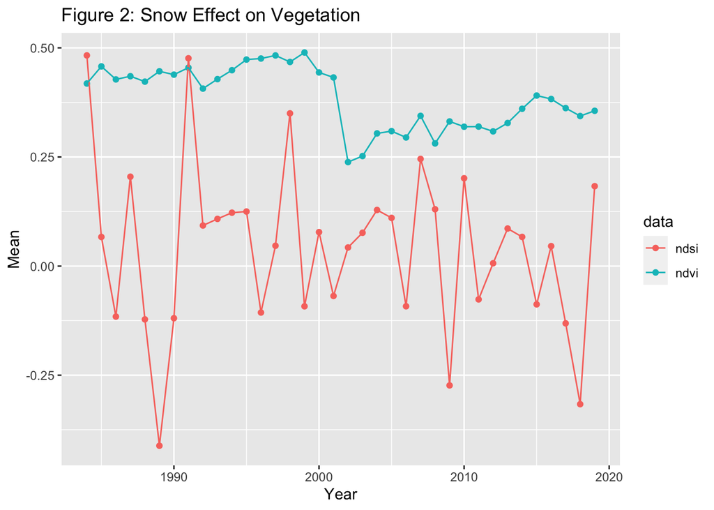

```r
#merge datasets
finaldf = rbind(NDSI_avgs, NDVI_avgs)

#plot
ggplot(finaldf) +aes(x=year, y=mean, color=data) +geom_point() +geom_line() + ggtitle('Figure 2: Snow Effect on Vegetation') +xlab('Year') +ylab('Mean')
```

## Question 3

How is the snow effect from question 2 different between pre- and post-burn and burned and unburned?

```r
#find averages for each year, for January-April
NDSI_avgs2 <- ndsi_long %>%
  mutate(month=month(DateTime), year=year(DateTime)) %>%
  filter(month %in% c(1,2,3,4)) %>%
  group_by(year, data, site) %>%
  summarize(mean = mean(value))
#find averages for each year, for June- August
NDVI_avgs2 <- ndvi_long %>%
  mutate(month=month(DateTime), year=year(DateTime)) %>%
  filter(month %in% c(6,7,8)) %>%
  group_by(year, data, site) %>%
  summarize(mean = mean(value))
```

[figure not shown]

```r
#merge datasets
finaldf2 = rbind(NDSI_avgs2, NDVI_avgs2)

#plot
ggplot(finaldf2) +aes(x=year, y=mean, color=data, shape = site) +geom_point() +geom_line() + ggtitle('Figure 3: Snow Effect on Vegetation At Two Sites Before and After 2003 Fire') +xlab('Year') +ylab('Mean')
```

## Question 4

What month is the greenest month on average?

```r
monthndvi <- ndvi_long %>%
  mutate(month=month(DateTime))

monthlymeans_NDVI <- monthndvi %>%
  group_by(month) %>%
  summarize(mean = mean(value))

kable(monthlymeans_NDVI, caption = 'NDVI Averages by Month')
```

NDVI Averages by Month

| month | mean |
| --- | --- |
| 1 | 0.2186012 |
| 2 | 0.1986539 |
| 3 | 0.2019000 |
| 4 | 0.2501716 |
| 5 | 0.3036180 |
| 6 | 0.3512811 |
| 7 | 0.3633104 |
| 8 | 0.3871568 |
| 9 | 0.3827147 |
| 10 | 0.3570475 |
| 11 | 0.2852874 |
| 12 | 0.2513979 |

NDVI is the normalized difference vegetation index, and determines the density of green on land. As such, I can find the average NDVI of different months and determine which month, on average, is the greenest. The averages range from 0.1986 (February) to 0.3871 (August). In other words, August was the greenest month on average. The second greenest was September at 0.3827. The least greenest month was February at 0.1986.

## Question 5

What month is the snowiest on average?

```r
monthndsi <- ndsi_long %>%
  mutate(month=month(DateTime))

monthlymeans_NDSI <- monthndsi %>%
  group_by(month) %>%
  summarize(mean = mean(value))

kable(monthlymeans_NDSI, caption = 'NDSI Averages by Month')
```

NDSI Averages by Month

| month | mean |
| --- | --- |
| 1 | 0.2099584 |
| 2 | 0.1988183 |
| 3 | -0.0420229 |
| 4 | -0.2278234 |
| 5 | -0.4105171 |
| 6 | -0.4409882 |
| 7 | -0.4504829 |
| 8 | -0.4594660 |
| 9 | -0.4539411 |
| 10 | -0.4085219 |
| 11 | -0.1151240 |
| 12 | 0.1241000 |

NDSI is the normalized difference snow index, and detects the presence of snow on land. As such, I can find the average NDSI of different months and determine which month, on average, is the snowiest The averages range from -0.4594 (August) to 0.2099 (January). In other words, January was the snowiest month on average. The second snowiest was February at 0.1988. The least snowiest month was August at -0.4594.

## Bonus Question: Redo all problems with `spread` and `gather` using modern tidyverse syntax.

## Bonus Question: Use Climate Engine to pull the same data for the assignment, but updated with 2020/2021 data.